# Capstone Project - ICU Mortality Prediction (Final)

## Summarize data post exclusions

- Some common exclusions that should be done:
  - Repeat observations, as noted in the previous section
  - Age, patients less than 18 years old
  - Surgical admits, which I am assuming in most cases are more likely to be elective than emergent
  - LOS, LOS<=1 (too short to use the first-day framework), >=30 (too long and probably representative of different kinds of admits), and nulls

```python
query = query_schema + """
with co as (
select
    icu.subject_id, hadm_id, icustay_id, intime, outtime
    , extract('epoch' from icu.intime - pat.dob) / 60.0 / 60.0 / 24.0 / 365.242 age
    ,EXTRACT(EPOCH FROM outtime - intime) /60.0/60.0/24.0 as icu_length_of_stay
    , rank() over (partition by icu.subject_id order by icu.intime) icustay_id_order
from
    icustays icu
    inner join patients pat on icu.subject_id = pat.subject_id
)

, serv as (
SELECT icu.hadm_id, icu.icustay_id, curr_service
    , case when curr_service like '%SURG' or curr_service = 'ORTHO' then 1 else 0 end surgical
    , case when curr_service in ('NB', 'NBB') then 1 else 0 end birth
    , case when curr_service in ('OBS', 'DENT', 'PSYCH') then 1 else 0 end minor_rep
    , rank() over (partition by icu.hadm_id order by se.transfertime desc) as rank
FROM
    icustays icu
    left join services se on icu.hadm_id = se.hadm_id
        and se.transfertime < icu.intime + interval '12' hour
)

, icd as (
select
    hadm_id
    ,subject_id
    ,max(case when seq_num = 1 then icd9_code else null end) icd1
    ,max(case when seq_num = 2 then icd9_code else null end) icd2
    ,max(case when seq_num = 3 then icd9_code else null end) icd3
    ,max(case when seq_num = 4 then icd9_code else null end) icd4
    ,max(case when seq_num = 5 then icd9_code else null end) icd5
    ,max(case when seq_num = 6 then icd9_code else null end) icd6
from
    diagnoses_icd
group by
    hadm_id
    ,subject_id

)

, deaths as (
select
    *
    , case when deathtime is not null then 1 else 0 end death
from admissions
)

select
    co.subject_id, co.hadm_id, co.icustay_id, co.intime
    , co.age, co.icu_length_of_stay los
    , death
    , icd1, icd2, icd3, icd4, icd5, icd6
    , icustay_id_order
    , serv.curr_service
    , case when co.age < 18 then 1 else 0 end exclusion_age
    , case when co.icustay_id_order <> 1 then 1 else 0 end exclusion_first_stay
    , case when serv.surgical = 1 or serv.curr_service is null then 1 else 0 end exclusion_surgical
    , case when serv.birth = 1 or serv.curr_service is null then 1 else 0 end exclusion_birth
    , case when serv.minor_rep = 1 or serv.curr_service is null then 1 else 0 end exclusion_minor_rep
    , case when co.icu_length_of_stay >= 30 or co.icu_length_of_stay <= 1 or co.icu_length_of_stay is null then 1 else 0 end exclusion_los
from
    co
    left join serv on co.icustay_id = serv.icustay_id and serv.rank = 1
    left join icd on co.hadm_id = icd.hadm_id
    left join deaths d on co.hadm_id = d.hadm_id
"""
df = pd.read_sql_query(query, con)
df.to_csv('alladmits.csv', sep='\t', encoding='utf-8', index=False)
```

```python
df = pd.read_csv('alladmits.csv', sep='\t')
display(df.shape)

print('{:20s} {:5d}'.format('Observations', df.shape[0]))
idxExcl = np.zeros(df.shape[0],dtype=bool)
for col in df.columns:
    if "exclusion_" in col:
        print('{:20s} {:5d} ({:2.2f}%)'.format(col, df[col].sum(), df[col].sum()*100.0/df.shape[0]))
        idxExcl = (idxExcl) | (df[col]==1)

# print a summary of how many were excluded in total
print('')
print('{:20s} {:5d} ({:2.2f}%)'.format('Total excluded', np.sum(idxExcl), np.sum(idxExcl)*100.0/df.shape[0]))
```

```
(61534, 21)
```

```
Observations         61534
exclusion_age         8200 (13.33%)
exclusion_first_stay 15058 (24.47%)
exclusion_surgical   19374 (31.49%)
exclusion_birth       9237 (15.01%)
exclusion_minor_rep   1167 (1.90%)
exclusion_los        13768 (22.37%)

Total excluded       42266 (68.69%)
```

```python
cohort = df[(df['exclusion_age'] == 0) &
            (df['exclusion_first_stay'] == 0) &
            (df['exclusion_surgical'] == 0) &
            (df['exclusion_birth'] == 0) &
            (df['exclusion_minor_rep'] == 0) &
            (df['exclusion_los'] == 0)]
cohort.info()
```

```
<class 'pandas.core.frame.DataFrame'>
Int64Index: 19268 entries, 0 to 61533
Data columns (total 21 columns):
subject_id              19268 non-null int64
hadm_id                 19268 non-null int64
icustay_id              19268 non-null int64
intime                  19268 non-null object
age                     19268 non-null float64
los                     19268 non-null float64
death                   19268 non-null int64
icd1                    19268 non-null object
icd2                    19241 non-null object
icd3                    19100 non-null object
icd4                    18785 non-null object
icd5                    18220 non-null object
icd6                    17397 non-null object
icustay_id_order        19268 non-null int64
curr_service            19268 non-null object
exclusion_age           19268 non-null int64
exclusion_first_stay    19268 non-null int64
exclusion_surgical      19268 non-null int64
exclusion_birth         19268 non-null int64
exclusion_minor_rep     19268 non-null int64
exclusion_los           19268 non-null int64
dtypes: float64(2), int64(11), object(8)
memory usage: 3.2+ MB
```

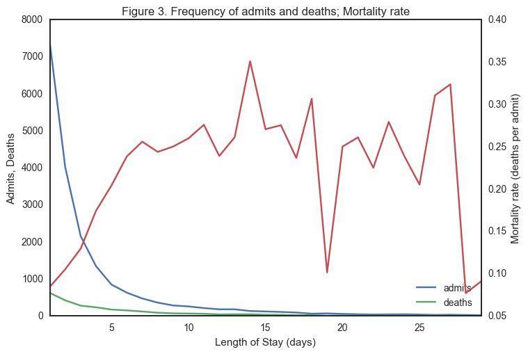

```python
df = cohort.copy()
df['los_group'] = np.floor(df.los)
df = df[['los_group', 'hadm_id', 'death']]
g = df.groupby('los_group').agg(OrderedDict([('hadm_id', 'count'),
                                             ('death', 'sum')
                                            ])).reset_index()
g.columns = ['los', 'admits', 'deaths']
g['mortality'] = g.deaths / g.admits

ax = g.plot(kind='line', x='los', secondary_y='mortality');
ax.set_title('Figure 3. Frequency of admits and deaths; Mortality rate');
ax.set_xlabel('Length of Stay (days)');
ax.set_ylabel('Admits, Deaths');
ax.right_ax.set_ylabel('Mortality rate (deaths per admit)');
ax.legend(loc='lower right');
```

```python
# calculate summary stats
rows = len(cohort.hadm_id)
unique_admits = len(cohort.hadm_id.unique())
unique_patients = len(cohort.subject_id.unique())
unique_icustays = len(cohort.icustay_id.unique())
admits_per_patient = unique_admits *1.0 / unique_patients
icustays_per_admit = unique_admits *1.0 / unique_icustays
avg_los = cohort.los.mean()
mortality = cohort.death.mean()

# output summary stats
keys = ['rows', 'unique_admits', 'unique_patients', 'unique_icustays', 'admits_per_patient', 'icustays_per_admit', 'avg_los', 'mortality']
values = [rows, unique_admits, unique_patients, unique_icustays, admits_per_patient, icustays_per_admit, avg_los, mortality]
summary = dict(zip(keys, values))
pd.DataFrame(summary.items()).T.reset_index(drop=True)
```

|  | 0 | 1 | 2 | 3 | 4 | 5 | 6 | 7 |
| --- | --- | --- | --- | --- | --- | --- | --- | --- |
| 0 | rows | avg_los | unique_patients | icustays_per_admit | unique_icustays | unique_admits | admits_per_patient | mortality |
| 1 | 19268 | 4.20886 | 19268 | 1 | 19268 | 19268 | 1 | 0.136184 |

```python
query = query_schema + """
select
    *
from d_icd_diagnoses
"""
icd = pd.read_sql_query(query, con)

df = cohort[['icd1']]
df['count'] = 1
df.columns = ['icd', 'count']
g = df.groupby('icd').sum().reset_index()
g.columns = ['icd9_code', 'frequency']
m = pd.merge(g, icd, on='icd9_code').sort_values(by='frequency', ascending=False)
m['percent_of_total'] = m['frequency'] / m['frequency'].sum() * 100
m['percent_cumsum'] = m['frequency'].cumsum() / m['frequency'].sum() * 100
m[['icd9_code', 'frequency', 'long_title', 'percent_of_total', 'percent_cumsum']].head(10)
```

|  | icd9_code | frequency | long_title | percent_of_total | percent_cumsum |
| --- | --- | --- | --- | --- | --- |
| 39 | 0389 | 1024 | Unspecified septicemia | 5.394300 | 5.394300 |
| 529 | 41071 | 787 | Subendocardial infarction, initial episode of ... | 4.145815 | 9.540115 |
| 783 | 51881 | 590 | Acute respiratory failure | 3.108044 | 12.648159 |
| 600 | 431 | 496 | Intracerebral hemorrhage | 2.612864 | 15.261023 |
| 733 | 486 | 366 | Pneumonia, organism unspecified | 1.928041 | 17.189064 |
| 522 | 41011 | 353 | Acute myocardial infarction of other anterior ... | 1.859559 | 19.048622 |
| 539 | 41401 | 351 | Coronary atherosclerosis of native coronary ar... | 1.849023 | 20.897645 |
| 525 | 41041 | 334 | Acute myocardial infarction of other inferior ... | 1.759469 | 22.657114 |
| 755 | 5070 | 333 | Pneumonitis due to inhalation of food or vomitus | 1.754201 | 24.411315 |
| 958 | 5849 | 256 | Acute kidney failure, unspecified | 1.348575 | 25.759890 |

- The top 10 causes of admits seem reasonable. Infection and cardiovascular (heart attack, stroke) causes are expected to be the largest drivers of admits in the medical ICU.
- Contribution to total is low on the individual cause level, so we will predict all mortalities as opposed to the top X causes.

## Data Preprocessing

- Pulling in all data collected on the first day

```python
def preprocess(df):
    output = pd.DataFrame(index=df.index)

    if 'charttime' in df:
        del df['charttime']

    for col, col_data in df.iteritems():

        # delete date columns
        #if col_data.dtype == np.datetime64:
        #    df.drop(col, axis=1)

        # if data is non-numeric, replace with...
        if col_data.dtype == object:
            col_data = col_data.replace(['None'], [np.NaN])

        # if data is categorical, create dummy variables
        if col_data.dtype == object:
            col_data = pd.get_dummies(col_data, prefix = col)

        # collect the revised columns
        output = output.join(col_data)

    return output

def aggflatten(df):
    cols = df.columns
    agg_funcs = ['mean', 'min', 'max']

    # group by unique identifiers and aggregate data
    g = df.groupby(['subject_id', 'hadm_id', 'icustay_id']).agg(agg_funcs)

    # concatenate variable with aggregation function, remove concatenated identifiers
    new_cols = [x + '_' + y for x in cols for y in agg_funcs]
    new_cols = [x for x in new_cols if not (x.startswith('subject_id') or x.startswith('hadm_id') or x.startswith('icustay_id'))]

    # drop old column hierarchy, set concatenated column names
    g.columns = g.columns.droplevel(0)
    g.columns = new_cols

    return g.reset_index()
```

```python
query = query_schema + """
select * from gcsfirstday
"""
df = pd.read_sql_query(query, con)
gcs = preprocess(df)
print 'gcs {}'.format(gcs.shape)

query = query_schema + """
select * from labsfirstday
"""
df = pd.read_sql_query(query, con)
lab = preprocess(df)
print 'lab {}'.format(lab.shape)

query = query_schema + """
select * from rrtfirstday
"""
df = pd.read_sql_query(query, con)
rrt = preprocess(df)
print 'rrt {}'.format(rrt.shape)

query = query_schema + """
select * from ventfirstday
"""
df = pd.read_sql_query(query, con)
ven = preprocess(df)
print 'ven {}'.format(ven.shape)

query = query_schema + """
select * from vitalsfirstday
"""
df = pd.read_sql_query(query, con)
vit = preprocess(df)
del vit['glucose_max']
del vit['glucose_min']
print 'vit {}'.format(vit.shape)
```

```
gcs (61532, 8)
lab (61532, 41)
rrt (61532, 4)
ven (61532, 4)
vit (59247, 25)
```

```python
# combine all first-day datasets together
frames = (gcs, lab, rrt, ven, vit)
keys = ['subject_id', 'hadm_id', 'icustay_id']

framed = vit.merge(
            ven.merge(
                rrt.merge(
                    lab.merge(gcs, how='outer', on=keys),
                        how='outer', on=keys),
                    how='outer', on=keys),
                how='outer', on=keys)

# inner join to cohort data to filter to records of interest
raw = cohort.merge(framed, how='inner', on=keys)
raw.shape
```

```
(19268, 88)
```

```python
# clean up dataset: drop unnecessary columns
cols = [c for c in raw.columns if not (c.startswith('seq_')
                                        or c.startswith('subject_id')
                                        or c.startswith('exclusion_')
                                        or c.startswith('icd')
                                        or c.startswith('icustay_id')
                                        or c.startswith('hadm_id')
                                        or c.startswith('intime')
                                        or c.startswith('los')
                                        or c.startswith('curr')
                                       )]
raw = raw[cols]
display(raw.shape)
```

```
(19268, 69)
```

```python
# save to file for easier loading next time
raw.to_csv('raw.csv', sep='\t', encoding='utf-8', index=False)
```

### Initial data visualization

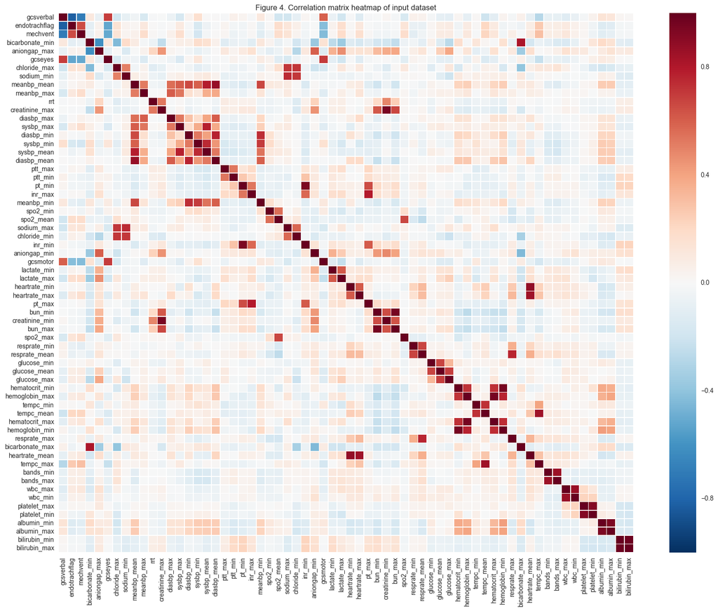

```python
# create correlation matrix
corr = raw.corr()

# unstack into database format to filter to highest relationships
#  only first considering correlation coefficients >= 0.3 and less than 0.9 (very high r belong
#  to obvious pairs, like bilirubin_min and bilirubin_max)
corrs = corr.unstack().reset_index()
corrs.columns=['first', 'second', 'r']
corrs = corrs[(abs(corrs['r']) >= 0.5) & #(abs(corrs['r']) < 0.9) &
              (abs(corrs['r']) <> 1)].sort_values(by='r', ascending=True)
highr = corrs['first'].unique()

# recreate correlation matrix with filtered set of variables
highcorr = raw[highr].corr()
f, ax = plt.subplots(figsize=(20,15))
sns.heatmap(highcorr, ax=ax, linewidths=0.5)

ax.set_title('Figure 4. Correlation matrix heatmap of input dataset')
ax.set_xticklabels(ax.xaxis.get_majorticklabels(), rotation=90)
ax.set_yticklabels(ax.yaxis.get_majorticklabels(), rotation=0)
plt.show()
```